# Why you should stop predicting customer churn and start using uplift models - ScienceDirect

## Figures (11)

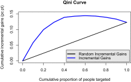

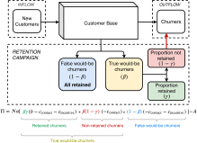

[figure not shown]

[figure not shown]

## [Information Sciences](https://www.sciencedirect.com/science/journal/00200255)

Available online 31 December 2019

[In Press, Corrected Proof](https://www.sciencedirect.com/science/journal/aip/00200255)

# Why you should stop predicting customer churn and start using uplift models

[FlorisDevriendt](https://www.sciencedirect.com/science/article/pii/S0020025519312022?via%3Dihub#!)[JeroenBerrevoets](https://www.sciencedirect.com/science/article/pii/S0020025519312022?via%3Dihub#!)[WouterVerbeke](https://www.sciencedirect.com/science/article/pii/S0020025519312022?via%3Dihub#!)

Under a Creative Commons [license](https://creativecommons.org/licenses/by-nc-nd/4.0/)

open access

## Highlights

**•**

Introduction of the maximum profit measure for evaluating uplift models.

**•**

Presentation of a real-world case study on uplift modeling for customer retention.

**•**

Customer churn uplift models are found to outperform customer churn prediction models.

**•**

Uplift modeling is concluded to be a superior tool for customer churn and retention management, increasing the returns on marketing investment.

## Abstract

Uplift modeling has received increasing interest in both the business analytics research community and the industry as an improved paradigm for predictive analytics for data-driven operational decision-making. The literature, however, does not provide conclusive empirical evidence that uplift modeling outperforms predictive modeling. Case studies that directly compare both approaches are lacking, and the performance of predictive models and uplift models as reported in various experimental studies cannot be compared indirectly since different evaluation measures are used to assess their performance.

Therefore, in this paper, we introduce a novel evaluation metric called the maximum profit uplift (MPU) measure that allows assessing the performance in terms of the maximum potential profit that can be achieved by adopting an uplift model. This measure, developed for evaluating customer churn uplift models, extends the maximum profit measure for evaluating customer churn prediction models. While introducing the MPU measure, we describe the generally applicable liftup curve and liftup measure for evaluating uplift models as counterparts of the lift curve and lift measure that are broadly used to evaluate predictive models. These measures are subsequently applied to assess and compare the performance of customer churn prediction and uplift models in a case study that applies uplift modeling to customer retention in the financial industry. We observe that uplift models outperform predictive models and lead to improved profitability of retention campaigns.

## Keywords

Prescriptive analytics

Uplift modeling

Customer churn prediction

Customer retention

Maximum profit

## 1. Introduction

### 1.1. Business analytics and predictive modeling

Business analytics is a catch-all term covering a broad variety of what essentially are data-processing techniques [1]. Business analytics are applied to an increasingly diverse range of well-specified tasks across a broad range of industries. Popular examples include applications in credit risk management [2], fraud detection [3], and customer relationship management, e.g., customer churn prediction [4], the latter being the application of interest in this article. In its broadest sense, the field of business analytics overlaps significantly with data science, statistics, and related fields such as *artificial intelligence* (AI) and machine learning [5]. Analytics are a toolbox containing a variety of instruments and methodologies allowing one to analyze data to support evidence-based decision-making for the purpose of enhancing efficiency, efficacy, and thus, ultimately, profitability. Various types of analytical tools, in the increasing order of complexity, are descriptive, diagnostic, predictive, and prescriptive analytics. While descriptive and diagnostic analytics offer insight into past and current situations, predictive analytics allow one to detect complex patterns and relations between variables and to predict future trends.

Customer churn prediction models, for instance, are designed to predict which customers are about to churn and to facilitate an accurate segmentation of the customer base to allow organizations to target the customers who are most likely to churn with a retention campaign. Doing so permits an efficient use of limited marketing budgets to reduce churn, i.e., to increase the *return on marketing investment* (ROMI) [6]. Generally, customer retention has been shown to be highly profitable to companies because (1) attracting new clients costs five to six times more than retaining existing customers [7], (2) long-term customers are more profitable, tend to be less sensitive to competitive marketing activities, tend to be less costly to serve, and may generate new referrals through positive word-of-mouth, whereas dissatisfied customers might spread negative word-of-mouth [8], and (3) losing customers leads to opportunity costs due to a reduction in sales [9]. Therefore, even a small improvement in customer retention may yield significant returns [10].

### 1.2. Prescriptive analytics and uplift modeling

The first challenge to traditional customer churn prediction models is that they do not fully align with their business objective, as they only predict the gross outcome, i.e., whether a customer will churn. Models estimating the net effect, however, focus on whether a customer is intent on churning AND will be retained when targeted with the campaign. The true business objective is to reduce customer churn. Customers who are about to churn but cannot be retained should be excluded from the campaign, as targeting them will be a waste of scarce resources. Moreover, it has been reported that retention efforts may also provoke customers to churn [11]. For instance, a retention offer may remind a customer about the imminent expiration of a contractual agreement and cause churn as a result. As noted in Radcliffe and Simpson [12], churn risk is highly correlated with customer dissatisfaction, and the goal in turn becomes that of preventing a dissatisfied customer from actually churning. Any attempt made to contact and retain a dissatisfied customer may actually provoke the customer to churn and thus contribute to a negative net effect of the campaign. Such customers are definitely to be excluded from a retention campaign and are to be distinguished those who will not churn regardless of whether they are targeted. Note that classic methods only differentiate customers who are about to churn from non-churners, while uplift modeling differentiates customers whose targeting will benefit the company from other customers. Targeting customers prescribed by an uplift model will not only reduce churn but do so with a lower resource expenditure, effectively resolving this first issue associated with traditional techniques.

**1.**

**2.**

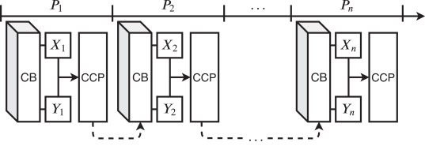

Fig. 1. Illustration of feedback loops causing future customer churn prediction models to be biased due to retention campaigns altering customer behavior. Data for the initial customer churn prediction model *P*<sub>1</sub> are collected during period 1, with the predictors gathered during the beginning of period 1 to predict churn at the end of period 1. Data for a novel customer churn prediction model *P*<sub>2</sub> are collected during period 2 while the first model involving retention campaigns altering customer behavior is used. In the figure, CB and CCP denote customer base and customer churn prediction, respectively.

### 1.3. Contributions

Despite a steadily growing body of literature on uplift modeling and theoretical evidence of the appropriateness of this approach, little conclusive empirical evidence of improved performance of uplift modeling over predictive modeling has been presented to date. Only [15] highlights the ineffectiveness of using standard churn prediction in two fields studies where uplift models are found to be more effective at retaining customers. Therefore, in this paper we further contrast *customer churn prediction* (CCP) and *customer churn uplift* (CCU) modeling for customer retention by comparing these approaches’ performance when they are applied to an experimental case study in the financial industry. CCP and CCU models, however, are evaluated using different evaluation approaches since they produce different kinds of output. For evaluating CCP models, the receiver operating characteristic (ROC) curve and the lift curve are often used. Performance is typically reported in terms of the area under the ROC curve (AUC) and top-decile lift. In evaluating uplift models, Qini curves and uplift-per-decile plots are typically used [16], and performance is commonly reported in terms of the Qini coefficient or top-decile uplift.

In this article, we develop a common evaluation procedure by extending the *maximum profit* (MP) measure to facilitate evaluation of the performance of CCU models. As the goal of customer churn prediction is to maximize ROMI, Verbeke et al. [17] introduced the MP measure for evaluating CCP models. This measure calculates the profit generated by a retention campaign when targeting the optimal proportion of top-ranked customers determined by a CCP model, given the cost and benefit parameters characterizing the retention campaign [18]. This measure allows selecting the optimal model and proportion of customers to be included in the campaign, potentially yielding a significant increase in profitability relative to the profit earned if statistical measures are used [19]. After the introduction of the extension of the MP, called the *maximum profit uplift* (MPU), we describe the generally applicable liftup curve and liftup measure that characterizes the performance of an uplift model. These serve as counterparts of the lift curve and lift measure that are broadly used for evaluating predictive models. Both the MP measure and the MPU measure introduced in this paper will be used to compare the performance of CCP and CCU models developed using logistic regression and random forest-based methods in an experimental case study.

In summary, our main contributions are threefold:

**1.**

We extend the maximum profit measure for evaluating uplift models by introducing the maximum profit uplift measure.

**2.**

We introduce the generally applicable liftup curve and liftup measure for evaluating uplift models that correspond to the lift curve and lift measure used for evaluating predictive models.

**3.**

We provide empirical evidence of the merits of uplift modeling versus predictive modeling by performing an experimental case study.

This paper is structured as follows. In Section 2, we first introduce customer churn prediction modeling before discussing uplift modeling as an alternative approach to predictive modeling. Next, in Section 3 the MP measure for CCP models is discussed and extended to facilitate its application to evaluation of customer churn’s uplift models. In Section 4, we describe the experimental design of the case study and subsequently discuss the results of our experiments. Finally, in Section 5, conclusions are presented.

## 2. Literature

In Section 2.1, customer churn prediction is introduced along with the current standard approaches described in the literature and adopted in the industry. Afterwards, in Section 2.2 we describe uplift modeling and discuss prominent uplift modeling techniques and performance measures for evaluating uplift models.

### 2.1. Customer churn prediction

Customer churn, also referred to as customer attrition or customer defection, is defined as the *loss* or outflow of customers from the customer base [1]. In saturated markets, limited opportunities exist or significant investments are required to attract new customers. Hence, retaining existing customers is considered essential to maintaining profitability. Established customers have been shown to be more profitable due to the lower cost of serving them, and the sense of brand loyalty they have developed over time renders them on average less likely to churn. Loyal customers tend to be satisfied customers who also serve as word-of-mouth advertisers, referring new customers to a given company. Within retention, two types of defections are considered: (1) total defection, the customer completely interrupts the relationship with the company [20], and (2) partial defection, the customer changes behaviour over time and interacts less and less with the company (e.g. purchase some goods from other companies). Some type of relationship with the customer still exists [20]. In the context of a financial institution, as described in the case study provided in Section 4, a definition of churn, i.e., active contract termination upon customer request, is naturally present in the data.

Customer retention efforts are typically supported by a customer churn prediction model, which is a classification model such as a logistic regression or a decision tree model [17]. Such a model estimates for each customer the probability of that customer churning during a subsequent period of time. The customers with the highest likelihood of churning can then be offered an incentive, e.g., a discount or another promotional offer, to encourage them to extend their subscription or to keep their account active. In summary, customers who are susceptible to churn are typically identified by a customer churn prediction model and by extension targeted with a retention campaign. Accurate predictions are perhaps the most apparent goal of developing a customer churn prediction model, but acquiring insights into what motivates customers to churn is valuable to an organization and is often the second objective of developing such a model. Comprehensible models can offer novel insights into correlations between customer characteristics and behavior, and the propensity to churn [6]. Such insights allow addressing factors leading to customers’ defections and taking preventive measures to avoid rather than to cure churn.

Numerous classification techniques, including traditional statistical methods such as logistic regression [18], nonparametric statistical models such as k-nearest neighbor models [21], decision trees [22], ensemble methods [4], support vector machines [23] and neural networks [24], have been used for churn prediction. Moreover, social network analysis has been successfully used to predict customer churn [25] and for survival analysis that can be used to analyze and estimate the time until a customer’s defection. Analyses of the latter type allow focusing on the profitability of a customer over the entire customer lifetime [26]. An extensive literature review of customer churn prediction modeling is provided by Verbeke et al. [6]. In Verbeke et al. [17], results of an extensive benchmarking study are reported that confirm the no-free-lunch theorem’s applicability to customer churn prediction, with no modeling technique consistently achieving the best performance across various datasets. A recent study of customer churn prediction is covered in [27].

### 2.2. Uplift modeling

In Section 2.2.1, a brief introduction to uplift modeling is provided. In Section 2.2.2, an overview of the most prominent uplift modeling techniques is presented. Finally, in Section 2.2.3, evaluation measures for assessing the performance of uplift models are discussed.

#### 2.2.1. Definition

Uplift models aim to estimate the net effect of applying *a treatment* to *an outcome*. Hence, uplift modeling is about estimating the individual treatment effect and therefore is equivalent to individual causal modeling under a strong ignorability assumption [28]. In marketing, a treatment may concern any action taken towards a customer, such as a discount offered to retain a customer.

Conceptually, a customer base can be divided into four categories along two dimensions, as shown in Table 1 [5], [29]:

**1.**

*Sure Things*. Customers who would never churn. Targeting *sure things* does not generate additional returns yet in fact leads to additional costs, i.e., the fixed costs of contacting a customer and possibly a cost related to a financial incentive offered to targeted customers.

**2.**

*Lost Causes*. Customers to churn regardless of campaign used. *Lost causes* will not generate additional revenues yet in fact generate additional costs, although the latter are lower than the costs of *sure things*, as *lost causes* in contrast to *sure things* do not take advantage of financial incentives being offered.

**3.**

*Persuadables*. Customers who do not churn *only because* they have been exposed to a retention campaign. They do not churn only if contacted and cause a campaign to generate additional revenues and, as such, a net profit after the subtraction of costs stemming from the inclusion of other types of customers.

**4.**

*Do-Not-Disturbs*. Customers who would churn *only because* they were exposed to a retention campaign. They will not churn if not targeted but will churn if they are. Populations targeted for retention efforts can have an adverse reaction, e.g., discontinuing the purchase of the delivered product or service. Including *do-not-disturbs* in a campaign thus generates no additional revenues but leads to considerable additional costs. This category is sometimes referred to as *sleeping dogs* since, as long as these customers are undisturbed, they will continue to provide benefits to the company.

Table 1. Four theoretical classes.

| Churn when targeted | Yes | Do-Not-Disturbs | Lost Causes |
| --- | --- | --- | --- |
|  | No | Sure Things | Persuadables |
|  |  | No | Yes |
|  |  | Churn when not targeted |  |

The aim of uplift modeling is to allow targeting of *persuadables* only. Note that this classification of customers is dependent on the campaign. It is possible for a customer to be a *lost cause* if a campaign offers a 5% discount on the next purchase while being a *persuadable* if offered a 20% discount. If the data analytics perspective is adopted, uplift modeling involves the determination of the optimal settings for *decision variables*, such as a dummy treatment variable reflecting whether a customer is targeted with a retention campaign, that optimize a certain outcome, e.g., customer retention. Although in almost all studies of uplift modeling for marketing applications the decision variables are dummy variables that indicate whether a customer is targeted or not, such variables may also be continuous or multivalued categorical variables, e.g., representing the amount of discount or the channel used to contact a customer. Uplift modeling may be applied in various settings and for a broad variety of purposes beyond retention and marketing (e.g., in personalized medicine [30] and persuasion modeling in political campaigns [31]).

Few cases of uplift modeling for customer retention have been documented. Radcliffe and Simpson [12] applied uplift modeling to data from two retention campaigns in telecommunications. One campaign was highly effective and profitable, whereas the other was observed to be counterproductive and yielding a net loss. Both campaigns’ outcomes in terms of reducing churn improved as a result of uplift modeling. Guelman et al. [32] applied uplift modeling in insurance. Although on average the treatment had an almost neutral impact on retention for the entire sample, the authors showed that a positive impact of treatment could be attained if specific subgroups of the customer base were selected using uplift modeling.

We assume that a sample of customers is divided into two groups defined as the treatment and control groups. A customer is either part of the treatment group, i.e., is exposed to the campaign, or part of the control group, i.e., is not exposed to the campaign. The sample should be stratified, i.e., it should have the same distribution of churners and non-churners, and the same distribution of customers in the treatment and control groups as the full set of samples. As a formal definition, let *X* be a vector of inputs or predictor variables, $X={x1,…,xn},$ and let *Y* be the binary outcome variable, *Y* ∈ {0, 1}, which indicates whether a customer churned. Let the treatment variable *T* denote whether a customer belongs to the treatment group ($T=1$) or to the control group ($T=0$). *P* denotes the probability of churn. Uplift is then defined for customer *i* with characteristics *x<sub>i</sub>* as the probability of churn (i.e., $yi=1$) if the customer is not treated (i.e., $ti=0$) minus the probability of churn if the customer is treated (i.e., $ti=1$):(1)$U(xi):=P(yi=1|xi;ti=0)−P(yi=1|xi;ti=1)$In essence, uplift is the difference in outcome, e.g., customer behavior, resulting from a treatment. Uplift modeling aims at estimating uplift as a function of treatment and customer characteristics. Individuals associated with high uplift are then targeted by the campaign; i.e., they are classified as persuadable for treatment $ti=1$.

#### 2.2.2. Techniques

Uplift modeling techniques can be classified into data preprocessing and data processing approaches. Methods of the first class apply traditional predictive analytics within an adapted setup for learning an uplift model, whereas those of the second class apply adapted predictive analytical methods to estimate uplift.

Data preprocessing approaches include transformation approaches [30], [33] that redefine a target variable, and approaches that allow one to estimate uplift by defining additional predictor variables that are incorporated within a standard predictive model [11].

Approaches of the first group define a transformed target variable that is estimated. Historical data containing information on observed customer behavior never allows classifying customers in the four groups shown in Table 1, as the net effect of treatment cannot be observed for an individual customer due to the fundamental problem of causal inference [34]. We can only know for sure whether a customer belonged to the treatment or control group and whether the customer churned. Hence, customers can be classified in the following four groups: treatment responders, treatment non-responders, control responders and control non-responders. Techniques such as Lai’s approach [33], [35] and *pessimistic uplift modeling* [36] use this classification to define a transformed target variable, transforming the uplift modeling problem into a binary classification problem. A standard classification technique can subsequently be applied to learn an uplift model.

*Data preprocessing approaches* of the second group extend the set of predictor variables to allow estimation of uplift. In Lo [11], Kane et al. [35], an uplift modeling approach that groups the treatment and control groups into a single sample for developing a predictive model is proposed. A dummy variable is introduced to denote the group of origin for each customer. Afterwards, a model is developed from (1) the original predictor variables, (2) the added dummy variable, and (3) additional interaction variables between the predictor and dummy variables. Subsequently, a standard classification method can be used, yielding an uplift model that allows predicting the probability of churn in treatment and no-treatment scenarios, the difference being the uplift.

Alternatively, uplift can be modeled directly. Given the group-based nature of the uplift modeling problem, the most frequently adopted direct estimation approaches are tree-based methods that subsequently split the population into smaller segments. Uplift tree approaches adapt well-known algorithms such as *classification and regression trees* (CART) [39] or *chi-squared automatic interaction detection* (CHAID) methods [40], applying modified splitting criteria and pruning approaches. Examples of tree-based uplift modeling approaches include significance-based uplift trees proposed in Radcliffe and Surry [37], decision trees using information theory-inspired splitting criteria presented in Rzepakowski and Jaroszewicz [41], and uplift random forest and causal conditional trees introduced in Guelman et al. [42].